# HR - 3D - Analysis

## Authors

- Carlos Ramos Mateos
- Miguel Ángel Mancheño Yustres
- Pablo Aguilera Onieva
- Javier Irigoyen Muñoz
- Javier Jiménez Rodríguez

## Reasoning

Now, we are going to study the 3D version of the Hindmarsh-Rose neuronal model, e.g., the one which is composed of three differential equations:

$$ \begin{gather*} \dot x = y - Ax^3 + Bx^2 + I - z \\ \dot y = C - Dx^2 - y \\ \dot z = r(s(x-x_1)-z) \\ \\ \text{Once more, here where $I$ will follow the next dynamic:} \\ I = \begin{cases} I(\infty), & \text{if there is not a pulse} \\ I_0, & \text{otherwise} \end{cases} \\ \end{gather*} $$

The complete Hindmarsh-Rose neuron mathematical model implementation can be found in the */lib/hindmarsh_rose.py* file, where it has been fully parameterized to support multiple scenarios.

Once more, to avoid long stabilization times of our system we will assign the following **initial values by default**: $$ \begin{gather*} x_0 = -0.8610800560651974, & y_0 = -2.7984503338411115, & z_0 = 0 \end{gather*} $$

## Workspace

Here we are going to import all the modules needed for the execution of the notebook.

Here it is important to mention the *hindmarsh_rose* and *Utils* packages, that have being implemented for the current practice.

The hindmarsh_rose package contains the implementation of the Hindmarsh & Rose neuronal model with several functions to calculate the differentials for the different type of conductances.

The Utils package, on the other side, provide several utility functions that allow to keep clean the notebook from repetitive or not relevant code.

```python
from scipy.integrate import odeint
import numpy as np
from collections import deque
from tqdm import tqdm
from numpy import linalg as LA

from lib.hindmarsh_rose import HindmarshRoseNeuron
from lib.Utils import plot_signal, plot_signal_3d

from lib.plot_utils import (OX_LABEL, OY_LABEL, TITLE)
from lib.plot_utils import add_plot_properties

import matplotlib.pyplot as plt
```

The following code is added to avoid having to reset the python kernel each time imported modules are modified.

```python
%load_ext autoreload
%autoreload 2
```

# THEORY ABOUT THE 3D HR MODEL

## Critical points

Now, we are going to study the 3D version of the Hindmarsh-Rose neuronal model, e.g., the one which is composed of three differential equations:

$$ \begin{gather*} \dot x = y - Ax^3 + Bx^2 + I - z \\ \dot y = C - Dx^2 - y \\ \dot z = r(s(x-x_1)-z) \end{gather*} $$

First we equals to zero:

\begin{gather*} \dot x = y - Ax^3 + Bx^2 + I - z = 0\\ \dot y = C - Dx^2 - y = 0 \\ \dot z = r(s(x-x_1)-z) = 0 \end{gather*}

In summary: $$ \begin{gather*} y - Ax^3 + Bx^2 + I - z = 0\\ y = C - Dx^2 \\ s(x-x_1)-z= 0 \rightarrow z = s(x-x_1) \end{gather*} $$

We substitute in the previous system, to get x:

$$ (C - Dx^2) - Ax^3 + Bx^2 + I - S(x-x_1) = 0 \\ C - Dx^2 - Ax^3 + Bx^2 + I - S(x-x_1) = 0 \\ -Ax^3 + (B-D)x^2 + C + I -S(x-x_1) = 0 \\ -Ax^3 + (B-D)x^2 + C + I -Sx + Sx_1 = 0 \\ -Ax^3 + (B-D)x^2 -Sx +(I + C + Sx_1) = 0 $$

We know that:

$$ I = 0, A = 1, B = 3, C = 1, D= 5, \mu = r = 0.005, S = 4, x_1= -1.6 $$

Then we have:

$$ -Ax^3 + (B-D)x^2 -Sx +(I + C + Sx_1) = 0 \\ -x^3 +(3 - 5)x^2 -4x + (0 + 1 + (4*(-1.6))) \\ -x^3 -2x^2 -4x + (1 - 6.4) \\ -x^3 -2x^2 -4x - 5.4 = 0 $$

We resolve:

```python
coefs = [-1, -2, -4, -5.4]
x_sols = np.roots(coefs)
x_sols
```

```
array([-1.60453453+0.j        , -0.19773273+1.82383217j,
       -0.19773273-1.82383217j])
```

We ignore all the solutions with imaginary part ($x$ has to be real!) and we replace our real $x=-1.6045$ in $y, z$: $$ \begin{gather*} x = -1.6045 \\ y = C - Dx^2 \\ z = s(x-x_1) \end{gather*} $$

```python
# parameters
c = 1; d = 5; x_1 = -1.6; s=4

# equations
x = x_sols[0]
y = c - d*(x*x)
z = s*(x - x_1)

print('x: ', x, 'y: ', y,  'z:', z)
```

```
x:  (-1.6045345328021483+0j) y:  (-11.872655334773043+0j) z: (-0.018138131208592867+0j)
```

## Critical points stability

Here we are going to study the nulclines viusally and obtaining their critical points eigenvalues.

Before working on these points we should compute the Jacobian of our dynamical system:

$$ \begin{pmatrix} \frac{\partial \dot x}{\partial x} & \frac{\partial \dot x}{\partial y} & \frac{\partial \dot x}{\partial z}\\ \frac{\partial \dot y}{\partial x} & \frac{\partial \dot y}{\partial y} & \frac{\partial \dot y}{\partial z}\\ \frac{\partial \dot z}{\partial x} & \frac{\partial \dot z}{\partial y} & \frac{\partial \dot z}{\partial z} \end{pmatrix} $$

Second, for $\dot y$ $$ \begin{gather*} \frac{\partial \dot y}{\partial x} = -2Dx\\ \frac{\partial \dot y}{\partial y} = -1 \\ \frac{\partial \dot y}{\partial z} = 0 \end{gather*} $$

Last, for $\dot z$

$$ \begin{gather*} \frac{\partial \dot z}{\partial x} = rS\\ \frac{\partial \dot z}{\partial y} = 0\\ \frac{\partial \dot z}{\partial z} = -r \end{gather*} $$

We end at:

$$ \begin{pmatrix} -3x^2 + 2Bx & 1 & -1\\ -2Dx & -1 & 0\\ rS & 0 & -r \end{pmatrix} $$

We know that: $$ I = 0, A = 1, B = 3, C = 1, D= 5, \mu = r = 0.005, S = 4, x_1= -1.6 $$

So: $$ \begin{pmatrix} -3x^2 + 6x & 1 & -1\\ -10x & -1 & 0\\ 0.02 & 0 & -0.005 \end{pmatrix} $$

```python
x = x_sols[0]
B = 3
D = 5
r = 0.005
S = 4

aux = np.array(
    [
        [-3*x**2 + 2*B*x, 1, -1],
        [-2*D*x, -1, 0],
        [r*S , 0, -r]
    ]
)
w, _ = LA.eig(aux)
w
```

```
array([-18.27834493+0.j,  -0.04569495+0.j,  -0.03176051+0.j])
```

We can see that our critical point is:

- Stable in the OX (real & negative).
- Stable in OY (real & negative).
- Stable in OZ (real & negative).

So, it could be a stable equilibrium!

```python
# Default values
A = 1
B = 3
C = 1
D = 5
S = 4

I_0 = 1
I_INF = 0

X_1 = -1.6

# common values
a = A
b = B
c = C
d = D
i = I_INF

# we will leave all the system in function of "x"
x_start, x_stop = (-2, 2)
y_start, y_stop = (-15, 5)

values = 1000
x = np.linspace(x_start, x_stop, values)
```

### OX - Nulcline

If we have $\dot x = 0$, then: $$ \begin{gather*} y - Ax^3 + Bx^2 + I - z &=& 0 \\ y &=& Ax^3 - Bx^2 - I + s(x - x_1) \end{gather*} $$

```python
def dx_nul(
        a: float, x: np.array, b: float, i: float,
        x_1: float, s: float, **kwargs):
    '''
    This method will obtain the dx/dt nulcline.

    :param a: A parameter.
    :param x: OX linespace.
    :param b: B parameter.
    :param i: I_inf/I_0 parameter
    :param x_1: X_1 parameter.
    :param s: S parameter.
    :return np.array: A series of float
    values with the dx/dt nulcline
    '''
    return a*(x*x*x) - b*(x*x) - i + s*(x - x_1)
```

```python
# nulclines
## dx
dx_nul_params = {
    'a': A,
    'x': x,
    'b': B,
    'i': I_INF,
    'x_1': X_1,
    's': S
}

dx_nul_vals = dx_nul(**dx_nul_params)
```

```
<module 'matplotlib.pyplot' from '/home/sertija/.conda/envs/nei_p2/lib/python3.8/site-packages/matplotlib/pyplot.py'>
```

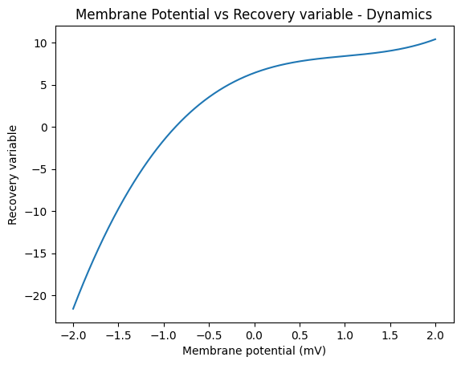

```python
plt.plot(x, dx_nul_vals)
add_plot_properties(
    plt, x_label=OX_LABEL, y_label=OY_LABEL, title=TITLE)
```

### OY - Nulcline

If we have $\dot y = 0$, then: $$ \begin{gather*} C - Dx^2 - y &=& 0 \\ y &=& C - Dx^2 \end{gather*} $$

```python
def dy_nul(c: float, d: float, x: np.array, **kwargs):
    '''
    This method will obtain the dy/dt nulcline.

    :param c: C parameter.
    :param d: D parameter.
    :param x: OX linespace.
    :return np.array: A series of float
    values with the dy/dt nulcline
    '''
    return c - d*(x*x)
```

```python
## dy
dy_nul_params = {
    'c': C,
    'd': D,
    'x': x,
}

dy_nul_vals = dy_nul(**dy_nul_params)
```

```
<module 'matplotlib.pyplot' from '/home/sertija/.conda/envs/nei_p2/lib/python3.8/site-packages/matplotlib/pyplot.py'>
```

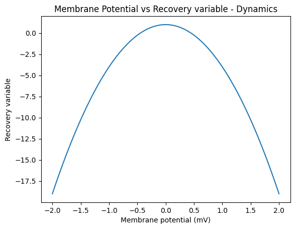

```python
plt.plot(x, dy_nul_vals)
add_plot_properties(
    plt, x_label=OX_LABEL, y_label=OY_LABEL, title=TITLE)
```

### OZ - Nulcline

If we have $\dot z = 0$, then: $$ \begin{gather*} z &=& sx - sx_1 \end{gather*} $$

```python
def dz_nul(x: np.array, x_1: float, s: float, **kwargs):
    '''
    dz/dt integration.

    :param x: OX linespace.
    :param x_1: X_1 parameter.
    :param s: S parameter.
    :return float: The system's integration.
    '''
    return s*x - s*x_1
```

```python
## dy
dz_nul_params = {
    'x': x,
    'x_1': X_1,
    's': S
}

dz_nul_vals = dz_nul(**dz_nul_params)
```

```
<module 'matplotlib.pyplot' from '/home/sertija/.conda/envs/nei_p2/lib/python3.8/site-packages/matplotlib/pyplot.py'>
```

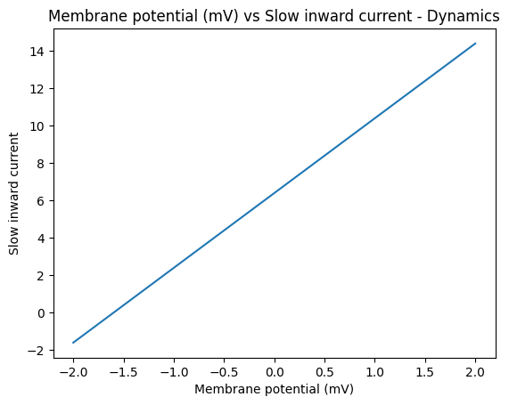

```python
plt.plot(x, dz_nul_vals)
add_plot_properties(
    plt, x_label=OX_LABEL,
    y_label='Slow inward current',
    title=OX_LABEL + ' vs ' + 'Slow inward current - Dynamics')
```

# SIMULATED CASES

These are the constants with the common values that are defined to be used in the whole notebook.

```python
A = 1
B = 3
C = 1
D = 5

# A = 1
# B = 2.6
# C = 1
# D = 5

I_INF = 0
I_SUP = 1

# I_INF = 2
# I_SUP = 1

STABLE_STATE = \
    (-0.8610800560651974, -2.7984503338411115, 0)
SILENT_STATE = \
    (0.6, 1, 0)

I_CASE = {
    'no_current': 0,
    'one_pulse_10ms': 1,
    'one_pulse_3ms': 2,
    'one_pulse_3ms_10ms': 3,
    'sustained_on': 4
}

SECONDS = 200
FRAME_RATE = 1000
NUMBER_OF_TICKS = SECONDS * FRAME_RATE
```

Here there is a dictionary with the generic parameters for the HR neurons. It's going to be used as a template for all the experiments.

```python
hr_params = {
    'e_i': 3,
    'a': A,
    'b': B,
    'c': C,
    'd': D,
    'mu': 0.00021,  # mu = r in the HR paper
    's': 4,
    'x1': -1.6,
    'state': SILENT_STATE,
    'delta_t': 0.001,
    'umbral_subida': -1.2,
    'umbral_bajada': -1.2,
    'hp_speed': 1,
    'dp_speed': 1,
    'mode_3d': True
}
```

## HR-3D system & pulse dynamic (I)

Here we are going to implement a function to generate a values series for the presynaptic current.

It's going to build it according to the type of experiment that we want to recreate with the neuron.

```python
def generate_i_sequence(length: int, case_type=0, i_inf=0, i_sup=1):

    zeros = np.ones(length, dtype=int) * i_inf  # I_CASE.no_current

    if case_type == I_CASE['one_pulse_10ms']:
        zeros[30*FRAME_RATE:40*FRAME_RATE] = i_sup
    elif case_type == I_CASE['one_pulse_3ms']:
        zeros[46*FRAME_RATE:49*FRAME_RATE] = i_sup
    elif case_type == I_CASE['one_pulse_3ms_10ms']:
        zeros[46*FRAME_RATE:49*FRAME_RATE] = i_sup
        zeros[89*FRAME_RATE:109*FRAME_RATE] = i_sup
    elif case_type == I_CASE['sustained_on']:
        zeros = np.ones(length, dtype=int) * i_sup

    pulse_sequence = deque(list(zeros))
    return pulse_sequence
```

The *generate_series* function generates time series for these variables:

- x: The membrane potential.
- y: The recovery variable, which in this case reflects the activity of potassium channels.
- z: The inward slow current, also known as the adaptation current.
- first_spikes: It contains the first spikes of the neuron bursts.
- hyperpol_points: It contains the points of maximum hyperpolarization.

```python
def generate_series(neuron: HindmarshRoseNeuron, pulse_sequence: None, repetitions=1, value_drops=0):

    x_array = []
    y_array = []
    z_array = []

    first_spikes = []
    hyperpol_points = []

    t_actual = 0

    is_there_first_spike = False

    drops = value_drops

    sequence_length = len(pulse_sequence)

    for t in tqdm(range(sequence_length * repetitions)):

        if pulse_sequence is None or len(pulse_sequence) == 0:
            e_i = 0
        else:
            e_i = pulse_sequence.popleft()
            pulse_sequence.append(e_i) # Con esto conseguimos que la cola doblemente terminada actúe como una cola circular

        new_state, spike, hiperpol = neuron.signal_step(e_i=e_i)

        t_actual += 1
        drops += 1

        if drops >= value_drops:
            x_array.append([t_actual, new_state[0]])
            y_array.append([t_actual, new_state[1]])
            z_array.append([t_actual, new_state[2]])
            drops = 0

        # Si ya hemos registrado el primer pico de la serie esperamos a bajar del umbral de activación para resetear el flag
        if new_state[0] < neuron.umbral_subida_:
            is_there_first_spike = False

        # Compruebo si se trata del primer spike
        if spike and not is_there_first_spike:
            first_spikes.append([t_actual, new_state[0]])
            is_there_first_spike = True

        # Compruebo si hay inicio de hiperpolarización
        if hiperpol:
            hyperpol_points.append([t_actual, new_state[0]])

    return x_array, y_array, z_array, first_spikes, hyperpol_points
```

The code in the following cell allows to interact with the 3d plot (in VS Code):

```python
%matplotlib widget
```

### Normal behaviour

With common values as:

```
stable_state = \
    (-0.8610800560651974, -2.7984503338411115, 0)
```

We can achieve a regular activity.

```python
hr_params_current = hr_params.copy()
hr_params_current['state'] = STABLE_STATE
```

```python
neuron = HindmarshRoseNeuron(**hr_params_current)
pulse_sequence = generate_i_sequence(length=NUMBER_OF_TICKS, case_type=I_CASE['no_current'], i_inf=I_INF, i_sup=I_SUP)
```

```python
x_array, y_array, z_array, _, _ = generate_series(neuron=neuron, pulse_sequence=pulse_sequence)
```

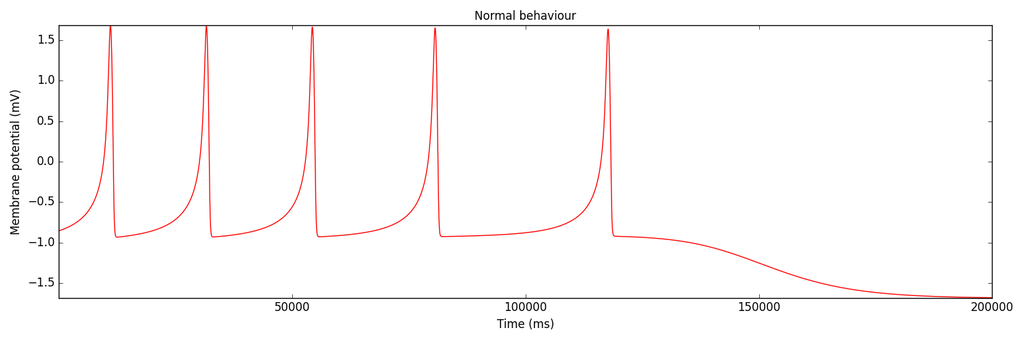

```python
plot_signal(potencial=x_array, title='Normal behaviour', x_label='Time (ms)', y_label='Membrane potential (mV)')
```

We note that, unlike the 2D model in which the dynamics remained oscillatory generating spikes at a fixed frequency, here the frequency decreases until we leave the oscillatory cycle.

This may be due to the inclusion of the z component which, as we have seen in the Hindmarsh and Rose paper, models an output current with a slower velocity compared to the other two variables.

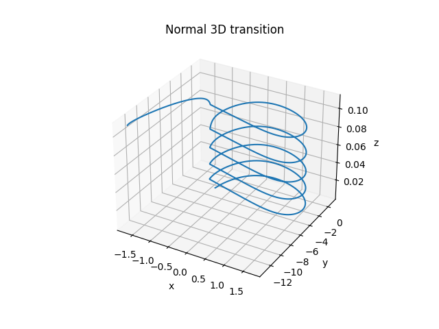

```python
plot_signal_3d(x_array, y_array, z_array, title='Normal 3D transition')
```

### Silent state

With a Membrane Potential at hyperpolarization values as:

```
silent_state = \
    (0.6, 1, 0)
```

We can achieve a silent behaviour of the neuron.

```python
hr_params_current = hr_params.copy()
hr_params_current['state'] = SILENT_STATE
```

```python
neuron = HindmarshRoseNeuron(**hr_params_current)
pulse_sequence = generate_i_sequence(length=NUMBER_OF_TICKS, case_type=I_CASE['no_current'], i_inf=I_INF, i_sup=I_SUP)
```

```python
x_array, y_array, z_array, _, _ = generate_series(neuron=neuron, pulse_sequence=pulse_sequence)
```

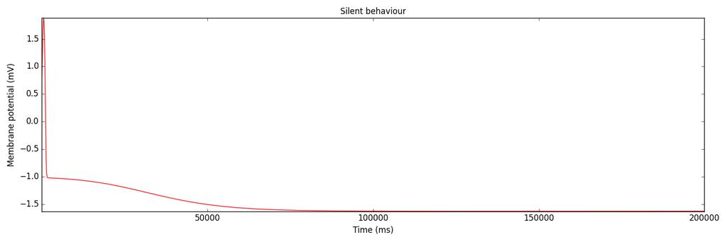

```python
plot_signal(potencial=x_array, title='Silent behaviour', x_label='Time (ms)', y_label='Membrane potential (mV)')
```

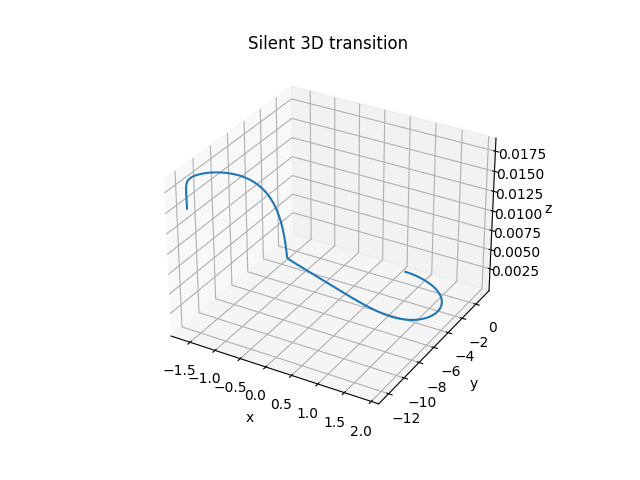

```python
plot_signal_3d(x_array, y_array, z_array, title='Silent 3D transition')
```

## Transition from Silent to Normal behaviour

From the previous silent state, giving a pulse of ~10-100ms we can achieve the following transition.

```python
hr_params_current = hr_params.copy()
hr_params_current['state'] = SILENT_STATE
```

```python
neuron = HindmarshRoseNeuron(**hr_params_current)
pulse_sequence = generate_i_sequence(length=NUMBER_OF_TICKS, case_type=I_CASE['one_pulse_10ms'], i_inf=I_INF, i_sup=I_SUP)
```

```python
x_array, y_array, z_array, _, _ = generate_series(neuron=neuron, pulse_sequence=pulse_sequence)
```

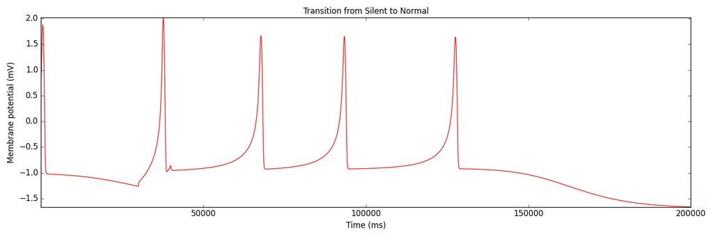

```python
plot_signal(potencial=x_array, title='Transition from Silent to Normal', x_label='Time (ms)', y_label='Membrane potential (mV)')
```

Here we observe the same behavior that we had in 2D, but with the same return to hyperpolarization that we saw in the Normal behavior of the neuron due to the Z component of the system.

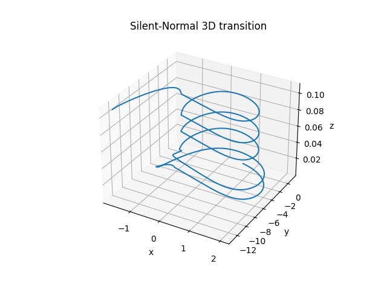

```python
plot_signal_3d(x_array, y_array, z_array, title='Silent-Normal 3D transition')
```

## Transition from Normal to Silent behaviour

Starting from the normal behaviour we can switch into a silent behaviour by adding a pulse in the peak of a spike for ~1-5ms.

```python
hr_params_current = hr_params.copy()
hr_params_current['state'] = STABLE_STATE
```

```python
neuron = HindmarshRoseNeuron(**hr_params_current)
pulse_sequence = generate_i_sequence(length=NUMBER_OF_TICKS, case_type=I_CASE['one_pulse_3ms'], i_inf=I_INF, i_sup=I_SUP)
```

```python
x_array, y_array, z_array, _, _ = generate_series(neuron=neuron, pulse_sequence=pulse_sequence)
```

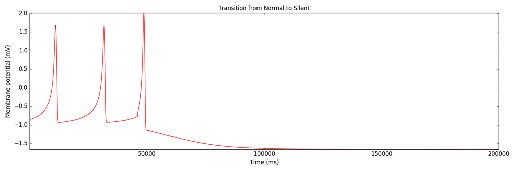

```python
plot_signal(potencial=x_array, title='Transition from Normal to Silent', x_label='Time (ms)', y_label='Membrane potential (mV)')
```

Here we have the same behavior as in 2D.

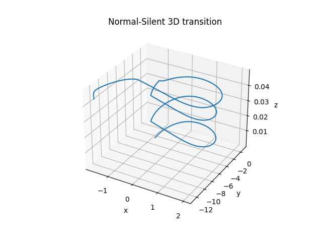

```python
plot_signal_3d(x_array, y_array, z_array, title='Normal-Silent 3D transition')
```

## Transition from Normal to Silent and from Silent to Normal

Here we are going to apply the previous two replicated dinamycs.

```python
hr_params_current = hr_params.copy()
hr_params_current['state'] = STABLE_STATE
```

```python
neuron = HindmarshRoseNeuron(**hr_params_current)
pulse_sequence = generate_i_sequence(length=NUMBER_OF_TICKS, case_type=I_CASE['one_pulse_3ms_10ms'], i_inf=I_INF, i_sup=I_SUP)
```

```python
x_array, y_array, z_array, _, _ = generate_series(neuron=neuron, pulse_sequence=pulse_sequence)
```

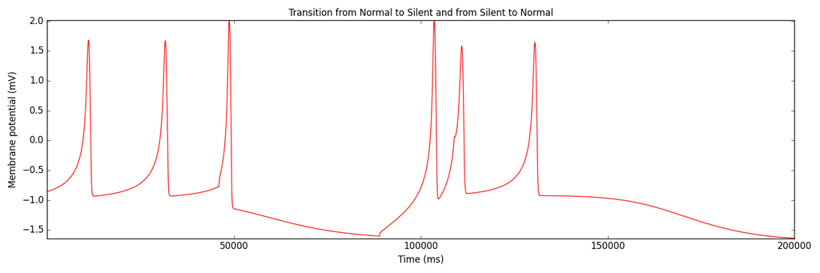

```python
plot_signal(potencial=x_array, title='Transition from Normal to Silent and from Silent to Normal', x_label='Time (ms)', y_label='Membrane potential (mV)')
```

We are able to replicate the same behavior as in 2D at the beginning (Normal->Silent->Normal), but due to the Z component of the system, after a few spikes the neuron returns to Silent state.

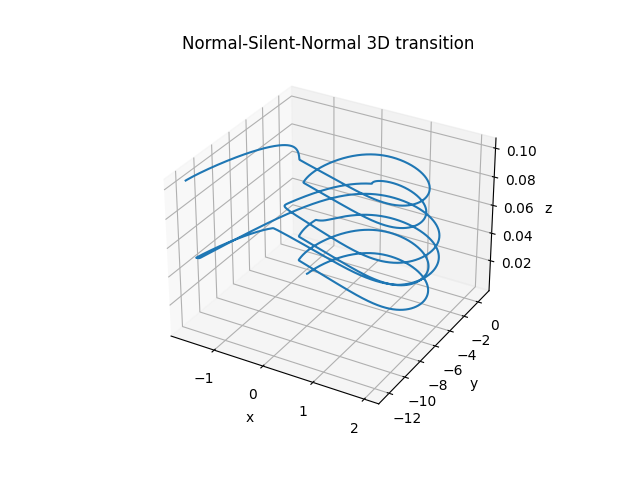

```python
plot_signal_3d(x_array, y_array, z_array, title='Normal-Silent-Normal 3D transition')
```

## Bursting activity

The 3D model introduces two new modes of operation in the neuron thanks to the addition of the third time-varying variable z. This allows the neuron to transition between two different dynamics when the current reaches a certain value (in our case I=2). This allows the neuron to transition between two different dynamics when the current reaches a certain value (in our case I=2), we are going to set the value of mu parameter to have a better view of the plot.

> **NOTE**

> Please remember that $\mu = r$ in our differential system.

```python
hr_params_current = hr_params.copy()
hr_params_current['mu'] = 0.001

I_SUP = 2
```

```python
neuron = HindmarshRoseNeuron(**hr_params_current)
NUMBER_OF_TICKS = 10 * SECONDS * FRAME_RATE
pulse_sequence = generate_i_sequence(length=NUMBER_OF_TICKS, case_type=I_CASE['sustained_on'], i_inf=I_INF, i_sup=I_SUP)
```

```python
x_array, y_array, z_array, _, _ = generate_series(neuron=neuron, pulse_sequence=pulse_sequence)
```

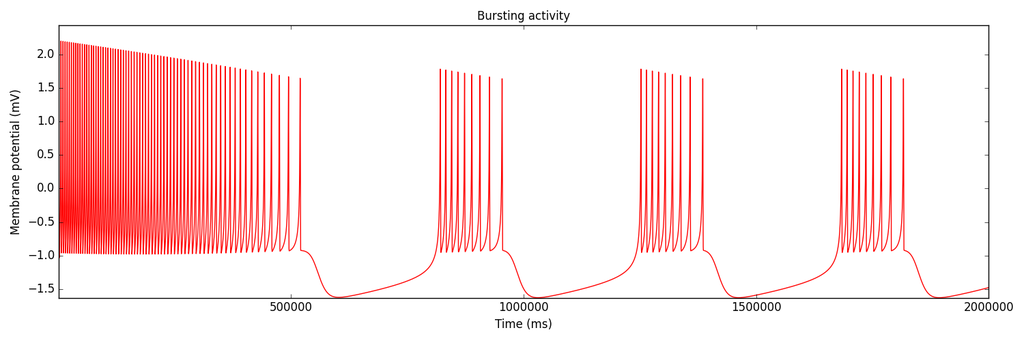

```python
plot_signal(potencial=x_array, title='Bursting activity', x_label='Time (ms)', y_label='Membrane potential (mV)')
```

Here we can see that the neuron enters into a bursting state along the time.

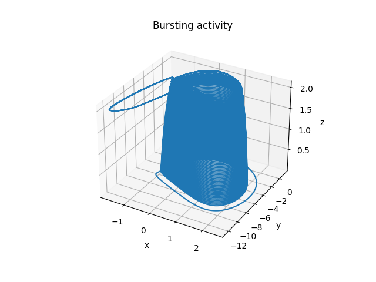

```python
plot_signal_3d(x_array, y_array, z_array, title='Bursting activity')
```

## Chaotic activity

As we said before, one of the operation modes that introduces the third variable (z) is the chaotic one. To put the neuron into this operation mode we need to increase the current (in our case I=3.281).

```python
hr_params_current = hr_params.copy()
hr_params_current['mu'] = 0.0021
# hr_params_current['mu'] = 0.0035

I_SUP = 3.281
```

```python
neuron = HindmarshRoseNeuron(**hr_params_current)
NUMBER_OF_TICKS = 20 * SECONDS * FRAME_RATE
pulse_sequence = generate_i_sequence(length=NUMBER_OF_TICKS, case_type=I_CASE['sustained_on'], i_inf=I_INF, i_sup=I_SUP)
```

```python
x_array, y_array, z_array, _, _ = generate_series(neuron=neuron, pulse_sequence=pulse_sequence)
```

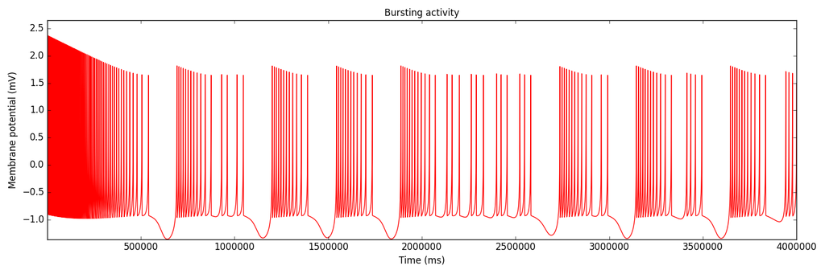

```python
plot_signal(potencial=x_array, title='Bursting activity', x_label='Time (ms)', y_label='Membrane potential (mV)')
```

In this plot we can see that the neuron enters into a chaotic regime.

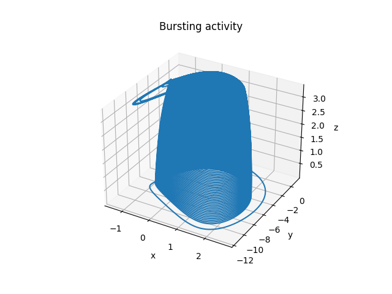

```python
plot_signal_3d(x_array, y_array, z_array, title='Bursting activity')
```

Finally, we think that it would be valuable to comment that, the previous 3D plots, show how our system enters into a Supercritical-Hopf Bifurcation switching between a limit cycle that ends into a stable mechanich which returns to the limit cycle in an infinite loop.

This mechanic explains how the bursting activity emerges where, the spiking peaks in the bursting mode, are explained by the limit cycle part while the silent periods between bursts is explained by the stable mechanich until it returns to the beginning of the limit cycle mechanic (burst-silence-burst-silence, ...)